# Availability Analysis

UCL Stochastic Systems (Fall 2024)

J. Tang

## Outline

Today we are going to talk about the Renewal Theory.

- A Story
- Problem Setup
- Alternating Renewal Model
- Code and Simulation
- Results

…and much more

## D’oh!

[video not shown]

## A Story

A manual shutdown was initiated during a start-up operation on February 25, 2009.

- At 4:03 AM, an alarm was triggered due to a pressure increase to 7.1 MPa, exceeding the regulatory limit of 6.91 MPa.
- It was confirmed that the alarm was caused by the shutting of a **turbine bypass valve**.
- At 8:49 AM, all control rods were inserted, and the reactor was manually shut down.

TEPCO. (2009). [Press Releases 2009-02-25](https://www.tepco.co.jp/cc/press/09022501-j.html). TEPCO, Tokyo.

## A Story Cont’d

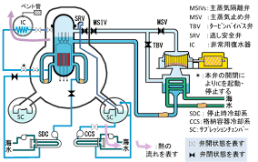

TEPCO. (2009). [Press Releases 2009-02-25](https://www.tepco.co.jp/cc/press/09022501-j.html). TEPCO, Tokyo.

## Objective

- To evaluate the performance of inspection and maintenance policies for standby safety installations onsite of a nuclear facility
- To solve the optimisation problem given system-specific parameters

## Problem Setup

## Problem Setup: Response Variables

| Variables | Description |
| --- | --- |
| `uptime` | System uptime (modelled by a Poisson process) |
| `downtime` | System downtime (due to a failure, inspection or maintenance) |
| `na` | Unavailability |

## Problem Setup: Explanatory Variables

| Variables | Description |
| --- | --- |
| `freq` | Inspection frequency |
| `mu` | Inspection rate |

## Problem Setup: Controlled Variables

| Variables | Description |
| --- | --- |
| `mtbf` | Mean time between failures |
| `gamma` | Repair rate |
| `n` | Relaxation time, $\tau$ (see Convergence Theorem and MCMC) |

See lecture slides: https://www.cl.cam.ac.uk/teaching/1819/Probablty/materials/Lecture3.pdf

## Some Key Questions

- How fast do they converge?
- How does inspection frequency affect system downtime?
- How does inspection duration affect the relationship between frequency and unavailability?

## Lemma 3.1

Consider a system that has time between failures $X_i \overset{\text{i.i.d.}}{\sim} \text{Exp}(\lambda)$ and some inspection frequency $f \in (0, \infty)$. The time elapsed during an undetected failure is given by
$$T \sim \text{U}(0, f^{-1})$$

## Lemma 3.1: Proof

Lemma 3.1 still holds for small inspection durations.

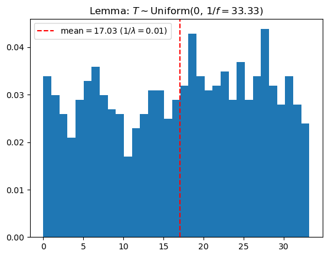

## Lemma 3.1: Proof Cont’d

The validity deteriorates for larger inspection durations.

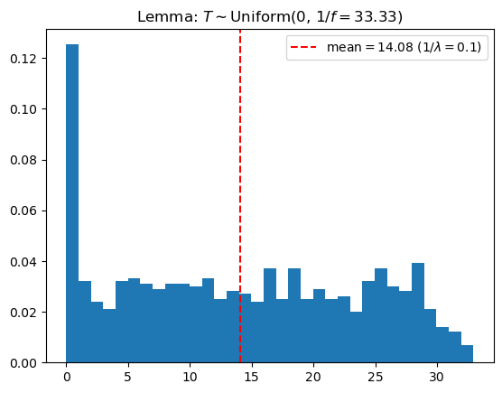

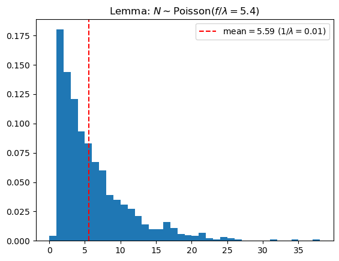

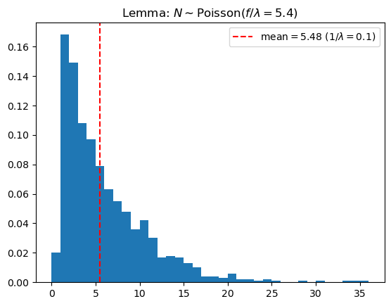

## Downtime due to Inspections

Assume $N$, $I$ are independent random variables. By the Law of Total Probability,
$$\mathbb{E}[N\cdot I]=\mathbb{E}[N]\mathbb{E}[I]=\frac{f}{\lambda\mu}$$

## Proposition 3.3

Consider $N$, $I$ are not independent

## Theorem 3.4

Consider a system that has time between failures $X_i \overset{\text{i.i.d.}}{\sim} \text{Exp}(\lambda)$, inspection duration $I_i \overset{\text{i.i.d.}}{\sim} \text{Exp}(\mu)$, repair time $M_i \overset{\text{i.i.d.}}{\sim} \text{Exp}(\gamma)$, and inspection frequency $f \in (0, \infty)$. The expectation of system unavailability, $O$, is given by
$$\mathbb{E}[O]=\frac{\mathbb{E}[N\cdot I]+\mathbb{E}[T]+\frac{1}{\mu}+\frac{1}{\gamma}}{\mathbb{E}[T]+\frac{1}{\lambda}+\frac{1}{\mu}+\frac{1}{\gamma}}$$

Using Lemma 3.1 and Lemma 3.2, we get
$$\mathbb{E}[O]=\frac{\frac{f}{\lambda\mu}+\frac{1}{2f}+\frac{1}{\mu}+\frac{1}{\gamma}}{\frac{1}{\lambda}+\frac{1}{2f}+\frac{1}{\mu}+\frac{1}{\gamma}}$$

A point to consider: is it safe to assume the independence between $N$ and $I$?

## More on Theorem 3.4

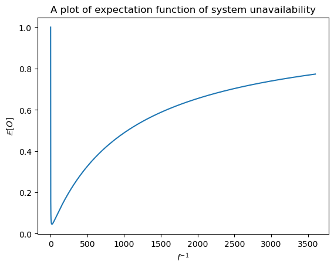

## General Solution

Let $g(f)=\frac{f}{\lambda\mu}+\frac{1}{2f}+\frac{1}{\mu}+\frac{1}{\gamma}$ and $h(f)=\frac{1}{\lambda}+\frac{1}{2f}+\frac{1}{\mu}+\frac{1}{\gamma}$.

## Theorem 3.5

For a system with $X_i \overset{\text{i.i.d.}}{\sim} \text{Exp}(\lambda)$, $I_i \overset{\text{i.i.d.}}{\sim} \text{Exp}(\mu)$, and $M_i \overset{\text{i.i.d.}}{\sim} \text{Exp}(\gamma)$, the expected system unavailability $\mathbb{E}[O]$ is minimised for frequency $f$ that satisfies the equation:
$$\zeta(f)=2\alpha^3 f^4 + 4\alpha^2 f^3 + (\frac{5}{2}\alpha - \lambda^2 \mu \alpha^2)f^2 + (\frac{1}{2} - \lambda^2 \mu\alpha)f - \frac{1}{4}\lambda^2 \mu=0$$
where $\alpha = \frac{1}{\lambda}+\frac{1}{\mu}+\frac{1}{\gamma}$.

## Code: A Simple Case

```python
import numpy as np

def step(freq, mtbf, gamma):

    downtime = 0
    uptime = np.random.exponential(mtbf)
    repair = np.random.exponential(1/gamma)

    for i in range(0, round(uptime*freq)):
        if # time to failure < ith inspection
            # failure detected, end the loop.

        elif # time to failure > ith inspection
            # no failure detected, continue.

    return online, offline
```

## Code: A Simple Case Cont’d

```python
import numpy as np

def step(freq, mtbf, gamma):

    downtime = 0
    uptime = np.random.exponential(mtbf)
    repair = np.random.exponential(1/gamma)

    for i in range(0, round(uptime*freq)):
        if uptime < i/freq:
            downtime += i/freq - uptime + repair
            break
        elif uptime > i/freq:
            offline += 0
            continue

    return online, offline
```

## Code: Alternating Renewal Processes

```python
import numpy as np

def inspection(step, mtbf, mu, gamma, n):

    inspect = list(range(30, n*365+step, step))
    online = []
    offline = []
    renewal = 0
    runtime = 0
    x=-1

    while runtime <= n*365:

        failure = np.random.exponential(mtbf)
        maintanence = np.random.exponential(1/gamma)

        for i in range(x+1, len(inspect)):

            if renewal + failure <= inspect[i]:
                duration = np.random.exponential(1/mu)
                online.append(failure+renewal-runtime)
                offline.append(inspect[i]-(failure+renewal)+duration+maintanence)
                runtime = sum(online) + sum(offline)
                renewal = inspect[i] + duration + maintanence
                x +=1
                break

            elif renewal + failure > inspect[i]:
                duration = np.random.exponential(1/mu)
                online.append(inspect[i]-runtime)
                offline.append(duration)
                runtime = sum(online) + sum(offline)
                x +=1
                continue


    na = sum(offline)/runtime
    return na
```

## Simulation

## Results

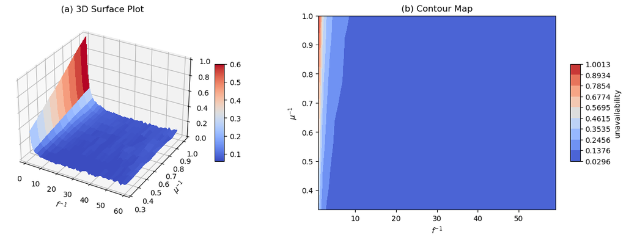

## Remarks

- When inspections take time, it gets messy!